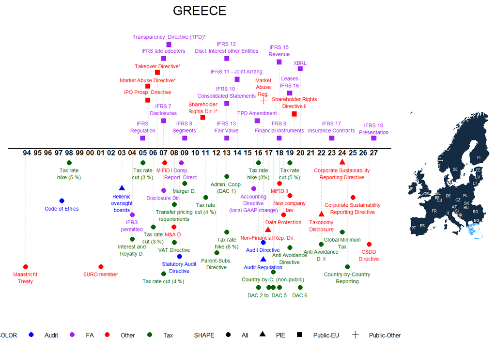

Notes: The graph depicts major regulatory changes that we identified via an extensive literature search, an online survey of mentioned authors, and other sources. Please note that the graph does not include all possible regulatory changes, e.g. minor revisions to local GAAP or tax rate changes below 3% are not included. The dates of EU Directives are based on the official transposition deadlines unless denoted with a *, in which case we included the entry-to-force date as identified in the literature. For more information, please go to [Labro and Pierk (2023)](http://www.eu-regulations.com/Labro_Pierk_2023.pdf). We kindly ask that you cite the paper if you use the information on this website in your research project. Do you have comments or see anything missing? Please email us!

## Regulations, Publications, Further Graphs

The tab ‘Regulations’ includes links to the regulations, gives short descriptions, and provides selective papers for further reading. If the regulation is a national transposition of an EU Directive, the link to the Directive is given. The tab ‘Number of Regulations’ shows graphically the number of regulations 8 years around the respective year (-4,-3,-2,-1,0,+1,+2,+3). The tab ‘Number of Categories” shows graphically the number of different categories 8 years around the respective year (-4,-3,-2,-1,0,+1,+2,+3). The tab ’Publications’ shows all publications that include the countries’ names and variations thereof in the title, abstract, or keywords. Similarly, the tab ‘SSRN’ shows papers of the SSRN Accouning Research Network that include the countries’ names and variations.

### Regulations

[output not shown]

[output cut: 57 more lines]

### Number of Regulations

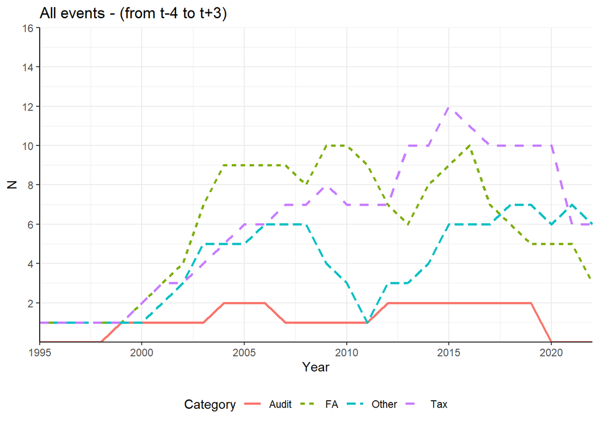

### Number of Categories

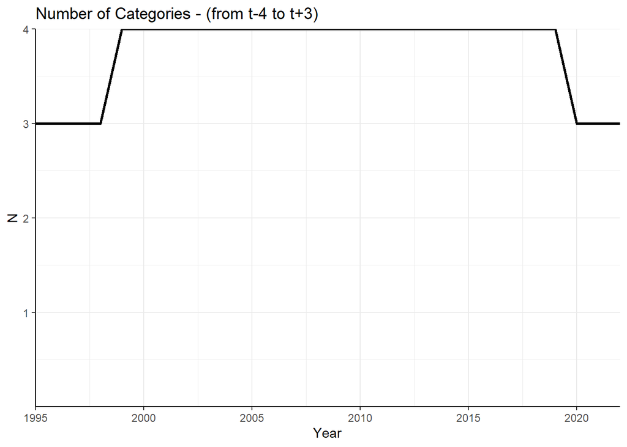

### Publications

|  | authors | title | year | journal |
| --- | --- | --- | --- | --- |
| 1 | Zisis V. | start-up firms and discretion over deferment of disclosure: an ex ante and an ex post perspective | 2021 | Accounting in Europe |
| 2 | Begkos C., Antonopoulou K. | measuring the unknown: evaluative practices and performance indicators for digital platforms | 2020 | Accounting, Auditing and Accountability Journal |
| 3 | Beuselinck C., Blanco B., García Lara J.M. | the role of foreign shareholders in disciplining financial reporting | 2017 | Journal of Business Finance and Accounting |
| 4 | Maddock L. | a quartet of poems | 2017 | Accounting, Auditing and Accountability Journal |
| 5 | Mantzari E., Sigalas C., Hines T. | adoption of the international financial reporting standards by greek non-listed companies: the role of coercive and hegemonic pressures | 2017 | Accounting Forum |
| 6 | Tsalavoutas I. | the role and current status of ifrs in the completion of national rules–evidence from greece | 2017 | Accounting in Europe |
| 7 | Dedoulis E. | institutional formations and the anglo-americanization of local auditing practices: the case of greece | 2016 | Accounting Forum |
| 8 | Gebhardt G. | impairments of greek government bonds under ias 39 and ifrs 9: a case study | 2016 | Accounting in Europe |
| 9 | Kartalis N., Tsamenyi M., Jayasinghe K. | accounting in new public management (npm) and shifting organizational boundaries: evidence from the greek show caves | 2016 | Accounting, Auditing and Accountability Journal |
| 10 | Makrygiannakis G., Jack L. | understanding management accounting change using strong structuration frameworks | 2016 | Accounting, Auditing and Accountability Journal |

[output cut: 30 more lines]

### SSRN

|  | authors | title | Posted | Revised |
| --- | --- | --- | --- | --- |
| 1 | Eli Bukspan | partial privatization and improved corporate performance – a reflection on the efficiencies of corporate social responsibility | 2021-11-18 |  |
| 2 | Christina Vadasi, Michalis Bekiaris and Andreas Andrikopoulos | corporate governance and internal audit: an institutional theory perspective | 2021-06-16 |  |
| 3 | Christos Grose, Dimitrios N. Koufopoulos, Dimitrios N. Koufopoulos, Ioannis P. Gkliatis, Konstantinos Athanasiadis and Michail Fygkioris | the audit committee in corporate governance | 2021-02-18 | 2021-02-23 |
| 4 | Vassilis Smaraidos, Vassilis Smaraidos, Georgios L. Thanasas and Georgia Kontogeorga | the adoption of the double-entry accounting system in the public hospitals of greece: the investigation of the degree of assimilation by the executives and the administration. | 2020-11-19 | 2020-11-20 |
| 5 | Maria Dimitriou | what is the importance of financial reporting from local gaap to ifrs for companies, and how can the accounting treatment influence this factor within firms’ valuation concept? | 2020-07-30 |  |
| 6 | Charoula Daskalaki and Nikolaos I. Karampinis | statutory auditors and tax compliance: evidence from a quasi-natural experiment | 2020-04-14 |  |
| 7 | Maria Dimitriou | the accounting treatment of firms’ valuation based on ifrs and greek gaap for appropriate investment decision making using ict | 2020-03-17 |  |
| 8 | Maria Dimitriou | case study of investment opportunities and decision making on food and drink firms listed on ase under ifrs | 2020-03-17 |  |
| 9 | Maria Dimitriou | a framework for accounting software and finance packages used in smes based on foss/floss | 2020-03-17 |  |
| 10 | Maria Dimitriou | ifrs and more recently ifrs for smes impact on financial statements compared to greek gaap: the case of smes in beverage industry | 2020-03-17 |  |

[output cut: 4 more lines]